# RNAseq Analysis with kallisto/Chris Deitrick, pt. 2

A continuation from RNAseq_ChrisAnalysis.Rmd

```r
library(dplyr)
library(tidyverse)
library(DESeq2)
library(knitr)
library(apeglm)
library(here)
library(pcaExplorer)
library(genefilter)
library(pheatmap)
library(RColorBrewer)
```

Here is defined as the project folder. Load workflow functions.

```r
here::here()
source(here("scripts", "deseq_workflow_expanded_mk3.r"), local=TRUE, echo=FALSE)
```

Running the DESeq2 workflow returns av DESeqObject, list of deseq::results (for each strain pairing), the counts table, design table, and annotation table. (The design and annotation tables are the same for each. Annotation tables will be sized down later in the analysis.)

```r
resultsFull <- des_workflow("data", "results/DESeq2_Results_Full","abundance.all.matrix.tsv", "plmd", "abundance.all.design.tsv", "annotations.tsv")
dOfull <- resultsFull[[1]]
drfull <- resultsFull[[2]]
counts_full <- resultsFull[[3]]
design_full <- resultsFull[[4]]
table_annotations <- resultsFull[[5]]

#And without chromosome 3
resultsFull <- des_workflow("data", "results/DESeq2_Results_Full/noChrom3","abundance.all.matrix.tsv", "both", "abundance.all.design.tsv", "annotations.tsv")
dOf <- resultsFull[[1]]
drf <- resultsFull[[2]]
cf <- resultsFull[[3]]
```

```r
resultsTilS <- des_workflow("data", "results/DESeq2_Results_TilS", "abundance.TilS.matrix.tsv", "plmd", "abundance.TilS.design.tsv", "annotations.tsv")
dOTilS <- resultsTilS[[1]]
drTilS <- resultsFull[[2]]
counts_TilS <- resultsFull[[3]]
design_TilS <- resultsFull[[4]]

#without chr3
resultsTilS <- des_workflow("data", "results/DESeq2_Results_TilS/noChrom3", "abundance.TilS.matrix.tsv", "both", "abundance.TilS.design.tsv", "annotations.tsv")
dOT <- resultsTilS[[1]]
drT <- resultsFull[[2]]
cT <- resultsFull[[3]]
```

```r
resultsFull <- des_workflow("data", "results/DESeq2_Results_PPC","abundance.PPC.matrix.tsv", "plmd", "abundance.PPC.design.tsv", "annotations.tsv")
dOPPC <- resultsFull[[1]]
drPPC <- resultsFull[[2]]
counts_PPC <- resultsFull[[3]]
design_PPC <- resultsFull[[4]]

#without Chr 3
resultsFull <- des_workflow("data", "results/DESeq2_Results_PPC/noChrom3","abundance.PPC.matrix.tsv", "plmd", "abundance.PPC.design.tsv", "annotations.tsv")
dOP <- resultsFull[[1]]
drP <- resultsFull[[2]]
cP <- resultsFull[[3]]
```

Now, creating a list of all of the objects and results to help process faster. The nameKey is ordered the same as the list, and then each item is named accordingly. (Most of the batching is being done later by only passing the name key to lapply(), and modifying each element of the globablly-defined list from within the function, to be able to use the name of the dataset within the function.)

```r
desObj <- list(dOfull, dOf, dOTilS, dOT, dOPPC, dOP)
desRes <- list(drfull, drf, drTilS, drT, drPPC, drP)
nameKey <- c("Full", "Full_nochr3", "TilS", "TilS_nochr3", "PPC", "PPC_nochr3")
names(desObj) <- nameKey
names(desRes) <- nameKey
```

## Filtering results

Using padj < 0.1 as the cutoff. Create list of data frames with signficant genes only for each pairing, from within the list of datasets. (Adding annotation description column, too.)

```r
desResSig <- lapply(desRes, function(matrixof) {
  lapply(matrixof[ ,1], function(df) {
    newdf <- df[order(df$pvalue), ]
    newdf <- subset(newdf, padj<0.1)
    newdf <- as.data.frame(newdf)
    newdf <- tibble::rownames_to_column(newdf, var="Gene")
    shortAno <- table_annotations[table_annotations$locusTag %in% newdf$Gene, ]
    newdf$annotation <- shortAno$name
    return (newdf)
  })
})
```

Collating pairwise results for each dataset, and writing to csv file in main results folder. Each gene can be listed multiple times, but will have column entries denoting with mutant compared to which mutant.

```r
desResCol <- lapply(nameKey, function(listitem){
  wordList <- as.list(names(desResSig[[listitem]]))
  newdf <- mapply( function(df, w ) {words <- unlist(strsplit(w, "_to_", fixed=TRUE))
    df <- cbind( df, "mutant"=rep(words[[1]], nrow(df)),
                        "comparedTo"=rep(words[[2]], nrow(df)))
    }, desResSig[[listitem]], wordList, SIMPLIFY = FALSE, USE.NAMES = FALSE)
  collated <- do.call(rbind, newdf)
  newfile <- here::here("results", paste0("collated_sigRes_",listitem,".csv"))
  write.csv(collated, file=newfile, row.names = FALSE)
  return (collated)
})
```

## Rlog transformations of each of the data sets.

Using the rlog transformations, as the data set is less than 30. ([For reasoning](https://bioconductor.org/packages/release/workflows/vignettes/rnaseqGene/inst/doc/rnaseqGene.html#the-variance-stabilizing-transformation-and-the-rlog))

The DESeq2Transform objects produced can be given to pcaExplorer as well.

```r
rld <- lapply(setNames(nameKey, nameKey), function(listitem){
  rlog(desObj[[listitem]], blind=TRUE)
})
```

Creating heatmaps from each of the rlog transformations.

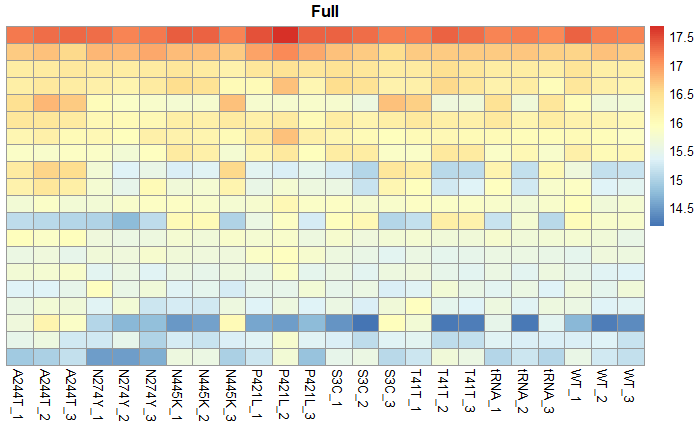

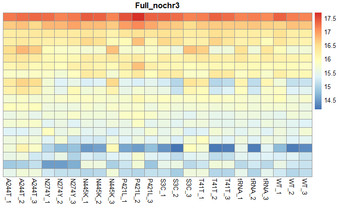

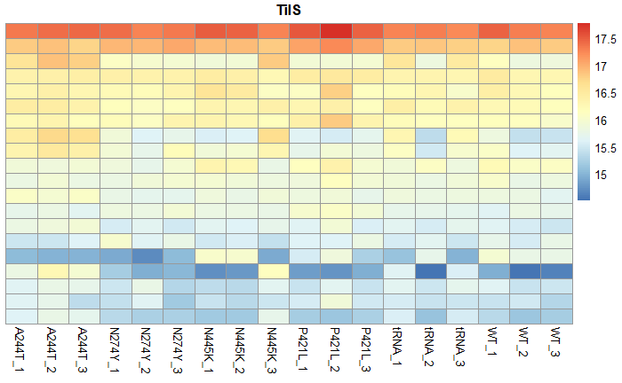

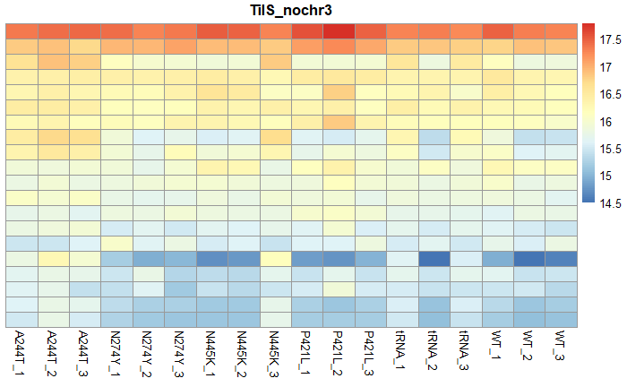

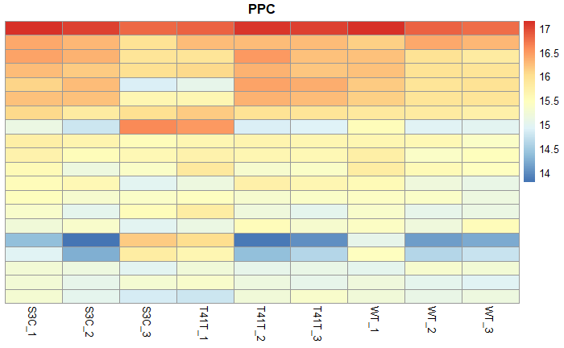

```r
select <- vector("list", 8)
select <- lapply(setNames(nameKey,nameKey), function(listitem){
  order(rowMeans(counts(desObj[[listitem]], normalized=TRUE)), decreasing=TRUE)[1:20]
})

df <- as.data.frame(colData(desObj[[1]])[,c("strain","type")]) #this is just a key

heatmaps <- lapply(setNames(nameKey,nameKey), function(listitem){
  pheatmap(assay(rld[[listitem]])[select[[listitem]],], cluster_rows=FALSE, show_rownames=FALSE,
           cluster_cols=FALSE, annoation_col=df, main = listitem)
})
```

Clustering

```r
colors <- colorRampPalette( rev(brewer.pal(9, "Blues")) )(255)

sampleDists <- vector("list", 8)
sampleDists <- lapply(setNames(nameKey,nameKey), function(listitem){
  sampleDists[[listitem]] <- dist(t(assay(rld[[listitem]])))
})
# sampleDistMatrix <- lapply(setNames(nameKey,nameKey), function(listitem){
#   as.matrix(sampleDists[[listitem]])
# })
# sampleDistMatrix <- lapply(nameKey, function(listitem){
#   rownames(sampleDistMatrix[[listitem]]) <- paste(rld[[listitem]]$strain, rld[[listitem]]$replicate, sep="-")
#  colnames(sampleDistMatrix[[listitem]]) <- NULL #In lapply, this is deleting whole element, instead of colnames.
# })
```

Clustering individually because I can’t get lapply to work.

```r
sampleDistMatrixfull <- as.matrix(sampleDists[["Full"]])
rownames(sampleDistMatrixfull) <- paste(rld[["Full"]]$strain, rld[["Full"]]$replicate, sep="-")
colnames(sampleDistMatrixfull) <- NULL
pheat_full <- pheatmap(sampleDistMatrixfull,
         clustering_distance_rows=sampleDists[["Full"]],
         clustering_distance_cols=sampleDists[["Full"]],
         col=colors, main = "Full data, no plasmid")
fname <- here::here("results", "rldClustering_Full.pdf" )
pdf(file = fname)
```

```r
dev.set(which = 2)
```

```r
dev.copy(which = 4)
```

```r
dev.off()
```

[figure not shown]

```r
sampleDistMatrixfullno3 <- as.matrix(sampleDists[[2]])
rownames(sampleDistMatrixfullno3) <- paste(rld[[2]]$strain, rld[[2]]$replicate, sep="-")
colnames(sampleDistMatrixfullno3) <- NULL
pheat_full_nochr3 <- pheatmap(sampleDistMatrixfullno3,
         clustering_distance_rows=sampleDists[[2]],
         clustering_distance_cols=sampleDists[[2]],
         col=colors, main = "Full data, no plasmid or chromosome 3")
```

```r
fname <- here::here("results", "rldClustering_Fullnochr3.pdf" )
pdf(file = fname)
dev.set(which = 2)
```

```r
dev.copy(which = 4)
```

```r
dev.off()
```

```r
sampleDistMatrixTilS <- as.matrix(sampleDists[[3]])
rownames(sampleDistMatrixTilS) <- paste(rld[[3]]$strain, rld[[3]]$replicate, sep="-")
colnames(sampleDistMatrixTilS) <- NULL
pheat_TilS <- pheatmap(sampleDistMatrixTilS,
         clustering_distance_rows=sampleDists[[3]],
         clustering_distance_cols=sampleDists[[3]],
         col=colors, main = "TilS subset, no plasmid")
fname <- here::here("results", "rldClustering_TilS.pdf" )
pdf(file = fname)
```

```r
dev.set(which = 2)
```

```r
dev.copy(which = 4)
```

```r
dev.off()
```

[figure not shown]

```r
sampleDistMatrixTilSno3 <- as.matrix(sampleDists[[4]])
rownames(sampleDistMatrixTilSno3) <- paste(rld[[4]]$strain, rld[[4]]$replicate, sep="-")
colnames(sampleDistMatrixTilSno3) <- NULL
pheat_TilS_nochr3 <- pheatmap(sampleDistMatrixTilSno3,
         clustering_distance_rows=sampleDists[[4]],
         clustering_distance_cols=sampleDists[[4]],
         col=colors, main = "TilS subset, no plasmid or chromosome 3")
```

```r
fname <- here::here("results", "rldClustering_TilSnochr3.pdf" )
pdf(file = fname)
dev.set(which = 2)
```

```r
dev.copy(which = 4)
```

```r
dev.off()
```

```r
sampleDistMatrixPPC <- as.matrix(sampleDists[[5]])
rownames(sampleDistMatrixPPC) <- paste(rld[[5]]$strain, rld[[5]]$replicate, sep="-")
colnames(sampleDistMatrixPPC) <- NULL
pheat_PPC <- pheatmap(sampleDistMatrixPPC,
         clustering_distance_rows=sampleDists[[5]],
         clustering_distance_cols=sampleDists[[5]],
         col=colors, main = "PPC subset, no plasmid")
fname <- here::here("results", "rldClustering_PPC.pdf" )
pdf(file = fname)
```

```r
dev.set(which = 2)
```

```r
dev.copy(which = 4)
```

```r
dev.off()
```

[figure not shown]

```r
sampleDistMatrixPPCno3 <- as.matrix(sampleDists[[6]])
rownames(sampleDistMatrixPPCno3) <- paste(rld[[6]]$strain, rld[[6]]$replicate, sep="-")
colnames(sampleDistMatrixPPCno3) <- NULL
pheat_PPC_nochr3 <- pheatmap(sampleDistMatrixPPCno3,
         clustering_distance_rows=sampleDists[[6]],
         clustering_distance_cols=sampleDists[[6]],
         col=colors, main = "PPC subset, no plasmid or chromosome 3")
```

```r
fname <- here::here("results", "rldClustering_PPCnochr3.pdf" )
pdf(file = fname)
dev.set(which = 2)
```

```r
dev.copy(which = 4)
```

```r
dev.off()
```

## PCA plots

Set a color scheme so that each mutant stays the same color.

```r
strainColors <- setNames(c("darkviolet", "dodgerblue3", "firebrick1", "green3",
                           "sienna3", "springgreen3", "cyan2", "orange2"), levels(design_full$strain))
```

Create, save, and store pca plots. (dimentions could be defined in the ggsave call)

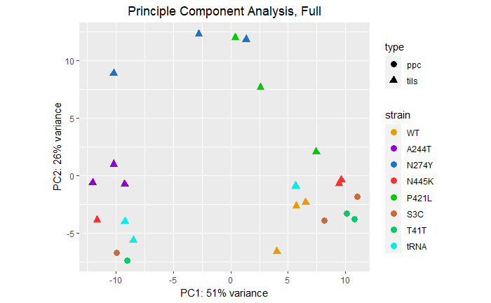

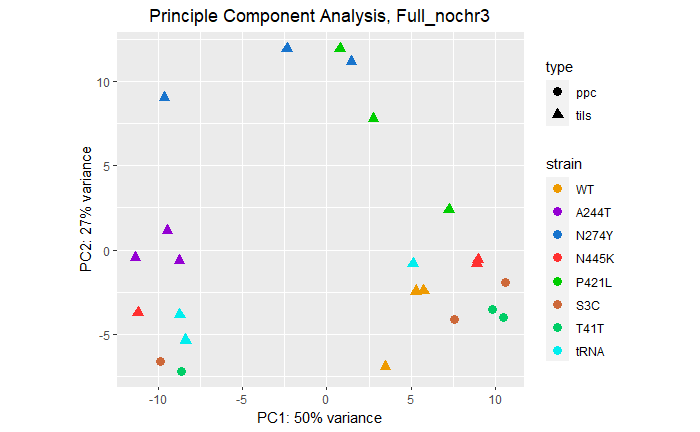

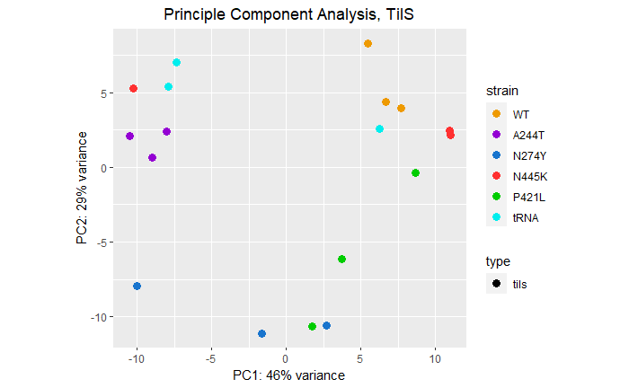

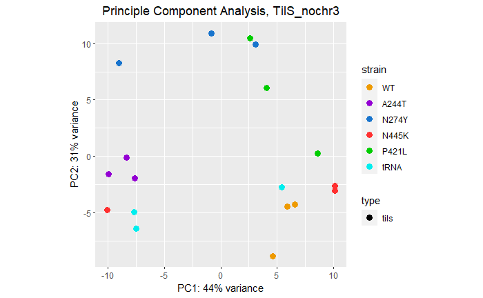

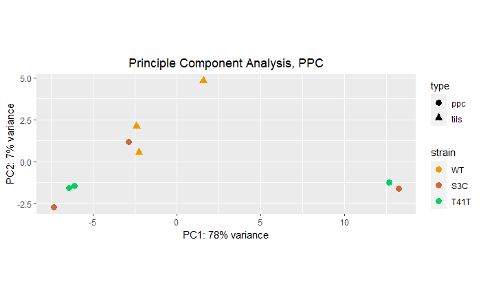

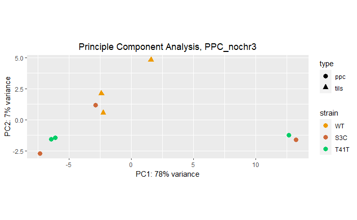

```r
dir.create(here::here("results","pca"), showWarnings = FALSE)
pcas <- lapply(setNames(nameKey,nameKey), function(listitem) {
  pcaData <- plotPCA(rld[[listitem]], intgroup=c("strain", "type"), returnData=TRUE)
  percentVar <- round(100 * attr(pcaData, "percentVar"))
  fname <- here::here("results", "pca", paste0("pcaPlot_", listitem, ".pdf"))
  p <- ggplot(pcaData, aes(PC1, PC2, color=strain, shape=type)) +
    geom_point(size=3) +
    xlab(paste0("PC1: ",percentVar[1],"% variance")) +
    ylab(paste0("PC2: ",percentVar[2],"% variance")) +
    coord_fixed() +
    ggtitle(paste0("Principle Component Analysis, ",listitem)) +
    theme(plot.title = element_text(hjust = 0.5)) +
    scale_color_manual(values = strainColors)
  ggsave(fname, device = "pdf")
  plot(p)
})
```

## PCA explorer

Creating a column that pcaExplorer expects, with the locus tag and annotation

```r
table_annotations$gene_name <- paste(table_annotations$locusTag, table_annotations$name, sep="-")
```

Running pcaExplorer on each data set. Mostly interested in the TilS and PPC subsets. Saving the top/bottom loading genes, and the variance explained by PC.

```r
pcaExplorer(dds = desObj[["Full"]], dst = rld[["Full"]], coldata = design_full, annotation = table_annotations)
```

```
Listening on http://127.0.0.1:6273
```

```
you provided 0 unique identifiers
```

```
NA
```

```r
pcaExplorer(dds = desObj[["Full_nochr3"]], dst = rld[["Full_nochr3"]], coldata = design_full, annotation = table_annotations)
```

```
Listening on http://127.0.0.1:6273
```

```
NA
```

```r
pcaExplorer(dds = desObj[["TilS"]], dst = rld[["TilS"]], coldata = design_full, annotation = table_annotations)
```

```r
pcaExplorer(dds = desObj[["TilS_nochr3"]], dst = rld[["TilS_nochr3"]], coldata = design_full, annotation = table_annotations)
```

```r
pcaExplorer(dds = desObj[["PPC"]], dst = rld[["PPC"]], coldata = design_full, annotation = table_annotations)
```

```r
pcaExplorer(dds = desObj[["PPC_nochr3"]], dst = rld[["PPC_nochr3"]], coldata = design_full, annotation = table_annotations)
```

## Filtering, not by log2 differential

Creating lists of highest variance genes (cutoff of 20), comparing with the average across all of the counts for particular genes. Because this takes into account variance, PPC and TilS should definitely be separated as the PPC counts are considerably lower.

```r
library("genefilter")

topVarGenes <- lapply(setNames(nameKey,nameKey), function(listitem){
  head(order(rowVars(assay(rld[[listitem]])), decreasing = TRUE), 20)
})

topVarEntries <- vector("list", length(nameKey))
topVarEntries <- lapply(setNames(nameKey, nameKey), function(listitem){
  topVarEntries[[listitem]]  <- assay(rld[[listitem]])[ topVarGenes[[listitem]], ]
})

gpheat <- lapply(setNames(nameKey, nameKey), function(listitem){
  mat  <- topVarEntries[[listitem]] - rowMeans(topVarEntries[[listitem]])
  anno <- as.data.frame(colData(rld[[listitem]])[, c("strain","type")])
  fname <- here::here("results", paste0("geneVarCluster_", listitem, ".pdf"))
  pdf(file=fname) # to save the pdf
  pheatmap(mat, annotation_col = anno, main = listitem)
  dev.off() # closes pdf
})
```

Save results

```r
topVarEntriesAno <- vector("list", length(nameKey))
topVarEntriesAno <- lapply(setNames(nameKey, nameKey), function(listitem){
  topVarEntriesAno[[listitem]] <- tibble::rownames_to_column(as.data.frame(topVarEntries[[listitem]]), var="locusTag")
  shortAno <- table_annotations[table_annotations$locusTag %in% topVarEntriesAno[[listitem]]$locusTag, ]
  topVarEntriesAno[[listitem]]$name <- shortAno$name
  fname <- here::here("results", paste0("TopVarianceGenes_",listitem,".csv"))
  write.csv(topVarEntriesAno[[listitem]], file=fname, row.names=FALSE)
})
```

#### Testing the gviz integration:

```r
txDB <- makeTxDbFromGFF(gtfFile, format="gtf")
```

```
Import genomic features from the file as a GRanges object ... OK
Prepare the 'metadata' data frame ... OK
Make the TxDb object ... The "phase" metadata column contains non-NA values for features of type stop_codon. This information was
  ignored.Error in .make_splicings(exons, cds, stop_codons) :
  some CDS cannot be mapped to an exon
```

Need rtrack information, or GRanges, or something like that.

#### Other apporach

```r
txdb <- makeTxDbFromGFF(here::here("data", "references", "GCA_000203955.1_ASM20395v1_genomic.gff"))
```

```
Import genomic features from the file as a GRanges object ... OK
Prepare the 'metadata' data frame ... OK
Make the TxDb object ... OK
```

```r
txdbRS <- makeTxDbFromGFF(here::here("data", "references", "GCF_000203955.1_ASM20395v1_genomic.gff"))
```

```
Import genomic features from the file as a GRanges object ... OK
Prepare the 'metadata' data frame ... OK
Make the TxDb object ... The following transcripts were dropped because their exon ranks could not be inferred (either because the
  exons are not on the same chromosome/strand or because they are not separated by introns):
  gene-BCEN2424_RS16455, gene-BCEN2424_RS17110, gene-BCEN2424_RS33785, gene-BCEN2424_RS34535OK
```

```r
txdb
```

```
TxDb object:
# Db type: TxDb
# Supporting package: GenomicFeatures
# Data source: C:/Users/mjf123/Documents/tilS/RNAseq/data/references/GCA_000203955.1_ASM20395v1_genomic.gff
# Organism: NA
# Taxonomy ID: NA
# miRBase build ID: NA
# Genome: NA
# transcript_nrow: 7005
# exon_nrow: 7005
# cds_nrow: 6919
# Db created by: GenomicFeatures package from Bioconductor
# Creation time: 2020-06-10 17:47:06 -0400 (Wed, 10 Jun 2020)
# GenomicFeatures version at creation time: 1.38.2
# RSQLite version at creation time: 2.2.0
# DBSCHEMAVERSION: 1.2
```

(note, using the GenBank one. Trascipt and exon count is the same, cds is different.) (The RefSeq one dropped gene-BCEN2424_RS16455, gene-BCEN2424_RS17110, gene-BCEN2424_RS33785, gene-BCEN2424_RS34535OK.)

(Having trouble using seqlevels with multiple chromosomes, so just combining multiple GRanges of transcripts) (see keys, keytypes, and select from GenomicFeatures for ways to pull genes of choice) Trying everything:

```r
head(seqlevels(txdb))
seqlevels(txdb) <- "CP000458.1"
ts <- vector("list", 3)
ts[[1]] <- transcripts(txdb)
seqlevels(txdb) <- "CP000459.1"
ts[[2]] <- transcripts(txdb)
seqlevels(txdb) <- "CP000460.1"
ts[[3]] <- transcripts(txdb)

tscripts <- c(ts[[1]], ts[[2]], ts[[3]])
tail(tscripts)
tscriptsno3 <- c(ts[[1]], ts[[2]])
tail(tscriptsno3)
seqlevels(txdb) <- seqlevels0(txdb) #Reset the filtering
```

*Having problems matching things up, I’m guessing because the annotation table used to construct the DESeqObject doesn’t have the same number of features as the transcript objects.*

Trying to find out where the problems are: Can try to find overlaps/gaps/see how many entries when disjointed using GRanges functions Can try to find if there are multiple etnries per locus_tag

```r
gaps(tscripts)
```

```
GRanges object with 6067 ranges and 0 metadata columns:
           seqnames          ranges strand
              <Rle>       <IRanges>  <Rle>
     [1] CP000458.1           1-177      +
     [2] CP000458.1       1756-1925      +
     [3] CP000458.1       3033-3223      +
     [4] CP000458.1       5699-6508      +
     [5] CP000458.1       8805-9307      +
     ...        ...             ...    ...
  [6063] CP000460.1 1049915-1049939      -
  [6064] CP000460.1 1052186-1052289      -
  [6065] CP000460.1 1053130-1053164      -
  [6066] CP000460.1 1054566-1054608      -
  [6067] CP000460.1 1055149-1055176      -
  -------
  seqinfo: 3 sequences from an unspecified genome; no seqlengths
```

```r
namelist <- mcols(tscripts)$tx_name
missingfeatures <- setdiff(namelist, rownames(dOTilS))
missingfeatures
```

```
 [1] "rna-Bcen2424_R0004" "rna-Bcen2424_R0005" "rna-Bcen2424_R0006" "rna-Bcen2424_R0007" "rna-Bcen2424_R0008"
 [6] "rna-Bcen2424_R0009" "rna-Bcen2424_R0010" "rna-Bcen2424_R0011" "rna-Bcen2424_R0012" "rna-Bcen2424_R0013"
[11] "rna-Bcen2424_R0014" "rna-Bcen2424_R0015" "rna-Bcen2424_R0016" "rna-Bcen2424_R0017" "rna-Bcen2424_R0018"
[16] "rna-Bcen2424_R0019" "rna-Bcen2424_R0020" "rna-Bcen2424_R0022" "rna-Bcen2424_R0025" "rna-Bcen2424_R0033"
[21] "rna-Bcen2424_R0034" "rna-Bcen2424_R0035" "rna-Bcen2424_R0036" "rna-Bcen2424_R0038" "rna-Bcen2424_R0039"
[26] "rna-Bcen2424_R0040" "rna-Bcen2424_R0045" "rna-Bcen2424_R0059" "rna-Bcen2424_R0060" "rna-Bcen2424_R0067"
[31] "rna-Bcen2424_R0068" "rna-Bcen2424_R0069" "rna-Bcen2424_R0070" "rna-Bcen2424_R0071" "rna-Bcen2424_R0073"
[36] "rna-Bcen2424_R0001" "rna-Bcen2424_R0002" "rna-Bcen2424_R0003" "rna-Bcen2424_R0021" "rna-Bcen2424_R0023"
[41] "rna-Bcen2424_R0024" "rna-Bcen2424_R0026" "rna-Bcen2424_R0027" "rna-Bcen2424_R0028" "rna-Bcen2424_R0029"
[46] "rna-Bcen2424_R0030" "rna-Bcen2424_R0031" "rna-Bcen2424_R0032" "rna-Bcen2424_R0037" "rna-Bcen2424_R0041"
[51] "rna-Bcen2424_R0042" "rna-Bcen2424_R0043" "rna-Bcen2424_R0044" "rna-Bcen2424_R0046" "rna-Bcen2424_R0047"
[56] "rna-Bcen2424_R0048" "rna-Bcen2424_R0049" "rna-Bcen2424_R0050" "rna-Bcen2424_R0051" "rna-Bcen2424_R0052"
[61] "rna-Bcen2424_R0053" "rna-Bcen2424_R0054" "rna-Bcen2424_R0055" "rna-Bcen2424_R0056" "rna-Bcen2424_R0057"
[66] "rna-Bcen2424_R0058" "rna-Bcen2424_R0061" "rna-Bcen2424_R0062" "rna-Bcen2424_R0063" "rna-Bcen2424_R0064"
[71] "rna-Bcen2424_R0065" "rna-Bcen2424_R0066" "rna-Bcen2424_R0072" "rna-Bcen2424_R0075" "rna-Bcen2424_R0076"
[76] "rna-Bcen2424_R0074" "rna-Bcen2424_R0077" "rna-Bcen2424_R0078" "rna-Bcen2424_R0079" "rna-Bcen2424_R0080"
[81] "rna-Bcen2424_R0081" "rna-Bcen2424_R0082" "rna-Bcen2424_R0083" "rna-Bcen2424_R0084" "rna-Bcen2424_R0085"
[86] "rna-Bcen2424_R0086"
```

No RNA features are in the deseq objects.

Check that there aren’t any repeated tx_names, then setting names by that column.

```r
namelist[duplicated(namelist)]
```

```
character(0)
```

```r
names(tscripts) <- mcols(tscripts)$tx_name
```

```r
write.csv(new_annotations, here::here("data", "new_annotations.tsv"), sep="\t")
```

```
attempt to set 'sep' ignored
```

Time for a new notebook. Going to restart with new reference for kallisto and annotations that includes the RNA features. See notebook 3.